# Intro to Univariate State-Space Models

19 Jan 2021

## Dickey-Fuller test with ‘ur.df’

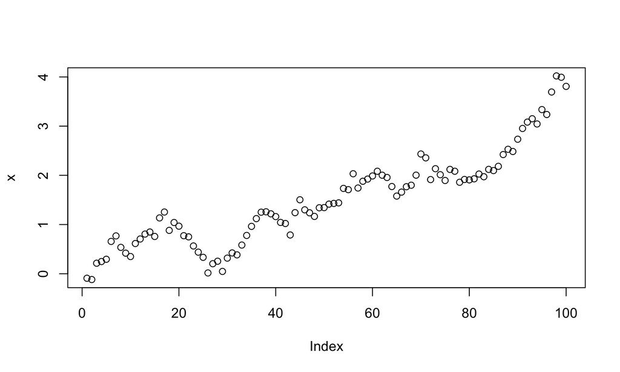

```r
x <- cumsum(rnorm(100, 0.02, 0.2))
plot(x)
```

## Dickey-Fuller stationarity test

\(x_t = \phi x_{t-1} + \mu + a t + e_t\)

\(x_t - x_{t-1} = \gamma x_{t-1} + \mu + a t + e_t\)

Test is for unit root is whether \(\gamma = 0\).

- Standard linear regression test statistics won’t work since the response variable is correlated with our explanatory variable.
- `ur.df()` reports the critical values we want in the summary info or `attr(test,"cval")`.

```r
library(urca)
test <- ur.df(x, type="trend", lags=0)
summary(test)
```

[output not shown]

```r
attr(test, "teststat")
```

```
##                tau3     phi2     phi3
## statistic -1.936144 2.970519 2.110123
```

```r
attr(test,"cval")
```

```
##       1pct  5pct 10pct
## tau3 -4.04 -3.45 -3.15
## phi2  6.50  4.88  4.16
## phi3  8.73  6.49  5.47
```

\(x_t = \phi x_{t-1} + \mu + a t + e_t\)

\(x_t - x_{t-1} = \gamma x_{t-1} + \mu + a t + e_t\)

The hypotheses reported in the output are

- `tau` (or `tau2` or `tau3`): \(\gamma=0\)
- `phi` reported values: are for the tests that \(\gamma=0\) and/or the other parameters \(a\) and \(\mu\) are also 0.

Since we are focused on the random walk (non-stationary) test, we focus on the `tau` (or `tau2` or `tau3`) statistics and critical values

## Univariate state-space models

Autoregressive state-space models fit a random walk AR(1) through the data. The variability in the data contains both process and non-process (observation) variability.

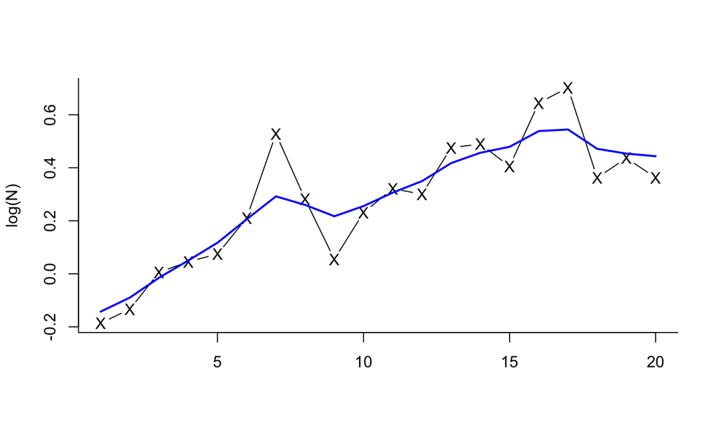

## PVA example

One use of univariate state-space models is “count-based” population viability analysis (chap 7 HWS2014)

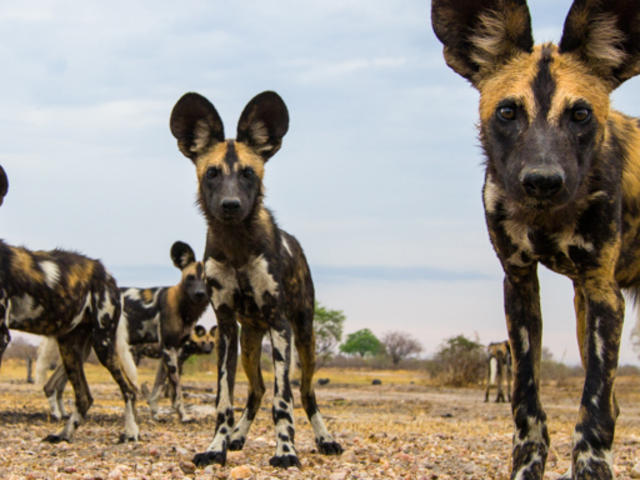

Imagine you were tasked with estimating the probability of the population going extinct (N=1) within certain time frames (10, 20, years).

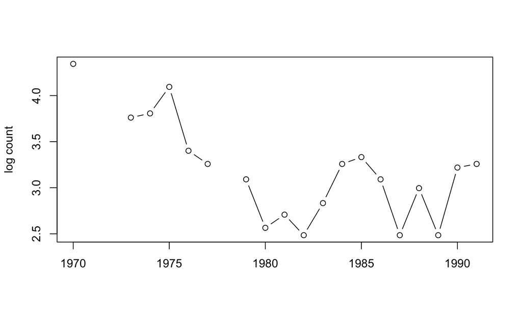

## How might we approach our forecast?

- Fit a model
- Simulate with that model many times
- Count how often the simulation hit N=1 (logN=0)

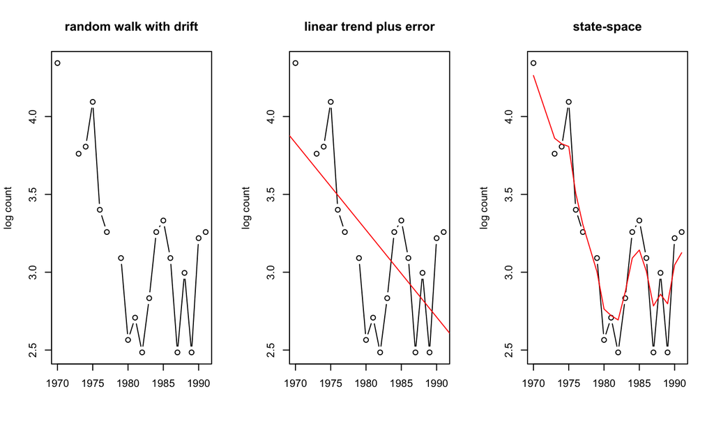

## How you model your data has a large impact on your forecasts

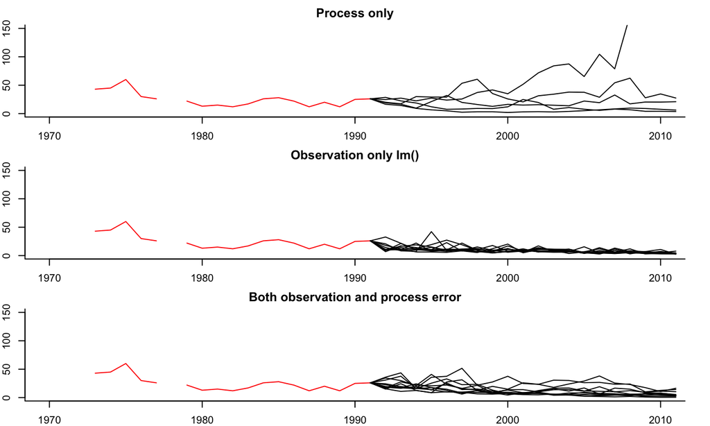

## Stochastic level models

Flat level

\[x = u\] \[y_t = x + v_t\]

Linear level

\[x_t = u + c \times t\] \[y_t = x_t + v_t\]

Stochastic level

\[x_t = x_{t-1} + u + w_t\] \[y_t = x_t + v_t\]

## Nile River example

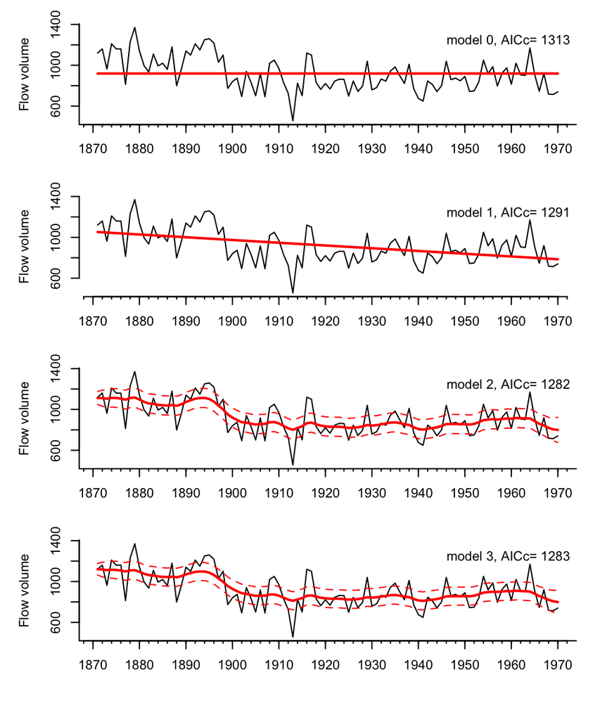

## Kalman filter and smoother

The **Kalman filter** is an algorithm for computing the expected value of the \(x_t\) conditioned on the data up to \(t-1\) and \(t\) and the model parameters.

\[x_t = b x_{t-1}+u+w_t, \,\,\, w_t \sim N(0,q)\]

\[y_t = z x_t + a + v_t, \,\,\, v_t \sim N(0,r)\]

The **Kalman smoother** computes the expected value of the \(x_t\) conditioned on all the data.

## Diagnostics

**Innovations residuals** =

data at time \(t\) minus model predictions given data up to \(t-1\)

\[\hat{y_t} = E[Y_{t}|y_{t-1}]\]

```
residuals(fit)
```

Standard diagnostics

- ACF
- Normality

## `MARSS package`

We will be using the MARSS package to fit univariate and multivariate state-space models.

\[\mathbf{x}_t = \mathbf{B}x_{t-1} + \mathbf{U} + \mathbf{w}_t, \,\,\, \mathbf{w}_t \sim MVN(0,\mathbf{Q})\] \[\mathbf{y}_t = \mathbf{Z}\mathbf{x}_{t} + \mathbf{A} + \mathbf{v}_t, \,\,\, \mathbf{v}_t \sim MVN(0,\mathbf{R})\]

The main function is `MARSS()`:

```
fit <- MARSS(data, model=list())
```

data are a univariate vector, univariate ts or a matrix with time going along the columns.

model list is a list with the structure of all the parameters.

## Univariate example

\[x_t = x_{t-1} + u + w_t, \,\,\, w_t \sim N(0,q)\] \[y_t = x_{t} + v_t, \,\,\, v_t \sim N(0,r)\]

Write where everything bold is a matrix.

\[x_t = \mathbf{B}x_{t-1} + \mathbf{U} + w_t, \,\,\, w_t \sim MVN(0,\mathbf{Q})\] \[y_t = \mathbf{Z}x_{t} + \mathbf{A} + v_t, \,\,\, v_t \sim MVN(0,\mathbf{R})\]

```
mod.list <- list(
  B = matrix(1), U = matrix("u"), Q = matrix("q"),
  Z = matrix(1), A = matrix(0), R = matrix("r"),
  x0 = matrix("x0"),
  tinitx = 0
)
```

## Let’s see some examples